# Veteran’s Life History and Psychological Health

A dataset from San Diego VA hospital

Shuai Shao, Shuyuan Shi, Xinyue Li

11/14/2019

In this group project, we will use github to record and track every team member’s work. You can find our project at [github repository](https://github.com/shaoshuai95/PSYC201A-project.git).

For this project, we are aiming to explore the veteran’s psychological health patterns in categories of depression, anxiety, sleep patterns, social connections, drug abuse, and social support.

In order to obtain data of veterans, we have got permission to access the dataset that records veterans’ treatment records from the VA hospital. Currently, we have demographic information (age, gender, ethnicity, social relationship status), alcohol usage, anxiety disorder scale, depression scale, emotional support, sleep patterns, BMI, and military service deployment (type, branch, number).

After conducting some preliminary analyses, we plan to gather more variables such as veteran’s social support, traumatic experience (such as childhood trauma and trauma during military service), substance abuse other than alcohol so that we can have a more overall analysis of the psychological health for veterans in the VA hospital. We can get necessary dataset by November 20th.

We plan to analyze:  
1) The relationship between veterans’ emotional support status and their anxiety/depression level (linear regression, correlation).  
2) The relationship between traumatic experiences, their substance abuse, and their anxiety levels (linear regression, multiple regression, correlation).  
3) The possible difference in types and branches of military service deployment and the veteran’s traumatic experiences (ANOVA, chi-squared test).  
4) The possible differences of all mentioned variables in gender, age, and ethnicity (linear regression, chi-squared test, t-test).  
5) We will also explore other possible relationships of the data.

## Demographical Variables

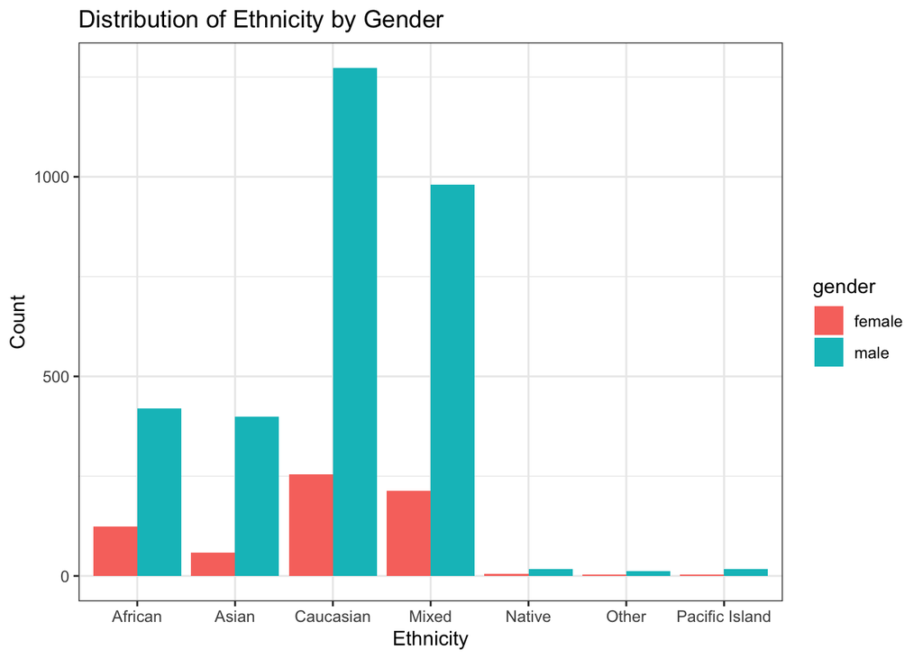

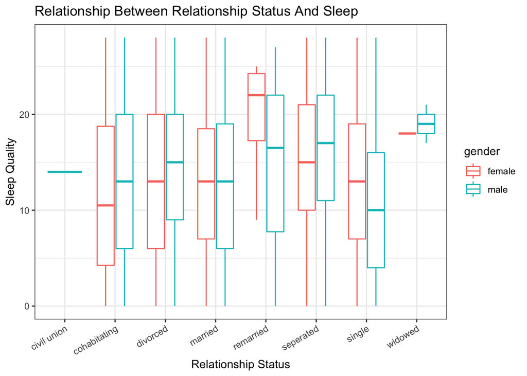

```
## Analysis of Variance Table
##
## Response: sleep_score
##                Df Sum Sq Mean Sq F value  Pr(>F)
## Relationship    7   6395  913.63 15.0289 < 2e-16 ***
## gender          1    179  179.20  2.9477 0.08609 .
## Residuals    3572 217147   60.79
## ---
## Signif. codes:  0 '***' 0.001 '**' 0.01 '*' 0.05 '.' 0.1 ' ' 1
```

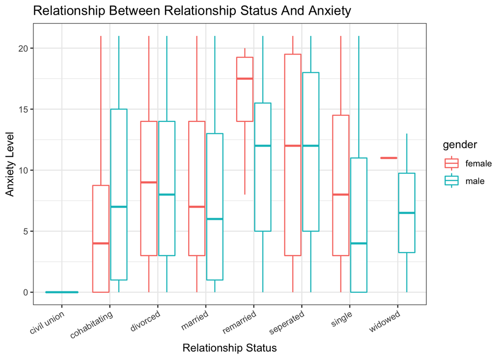

```
## Analysis of Variance Table
##
## Response: gad7_score
##                Df Sum Sq Mean Sq F value    Pr(>F)
## Relationship    7   4675  667.81  14.762 < 2.2e-16 ***
## gender          1    707  706.61  15.620 7.893e-05 ***
## Residuals    3571 161543   45.24
## ---
## Signif. codes:  0 '***' 0.001 '**' 0.01 '*' 0.05 '.' 0.1 ' ' 1
```

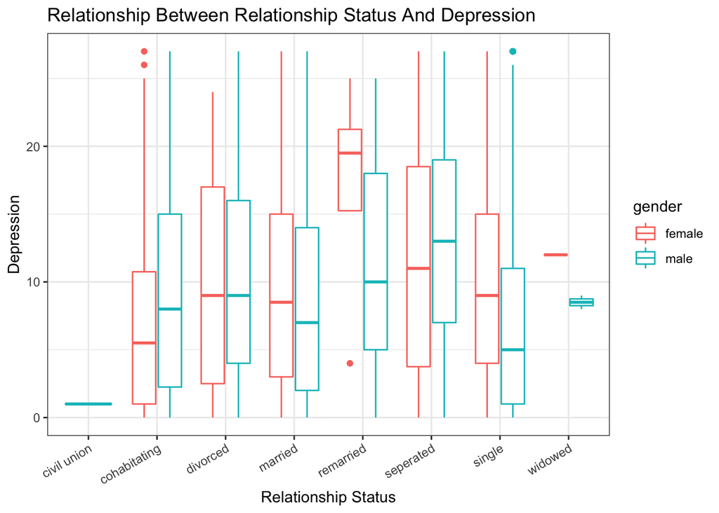

[output not shown]

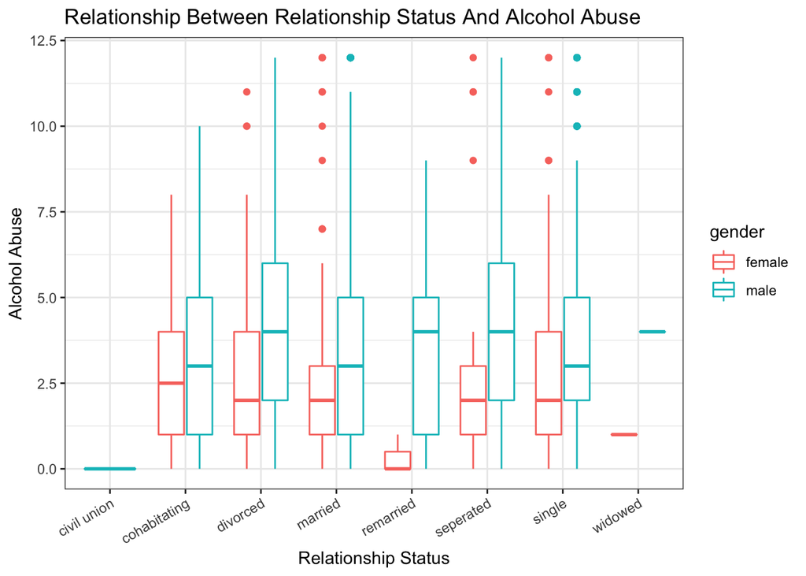

[output not shown]

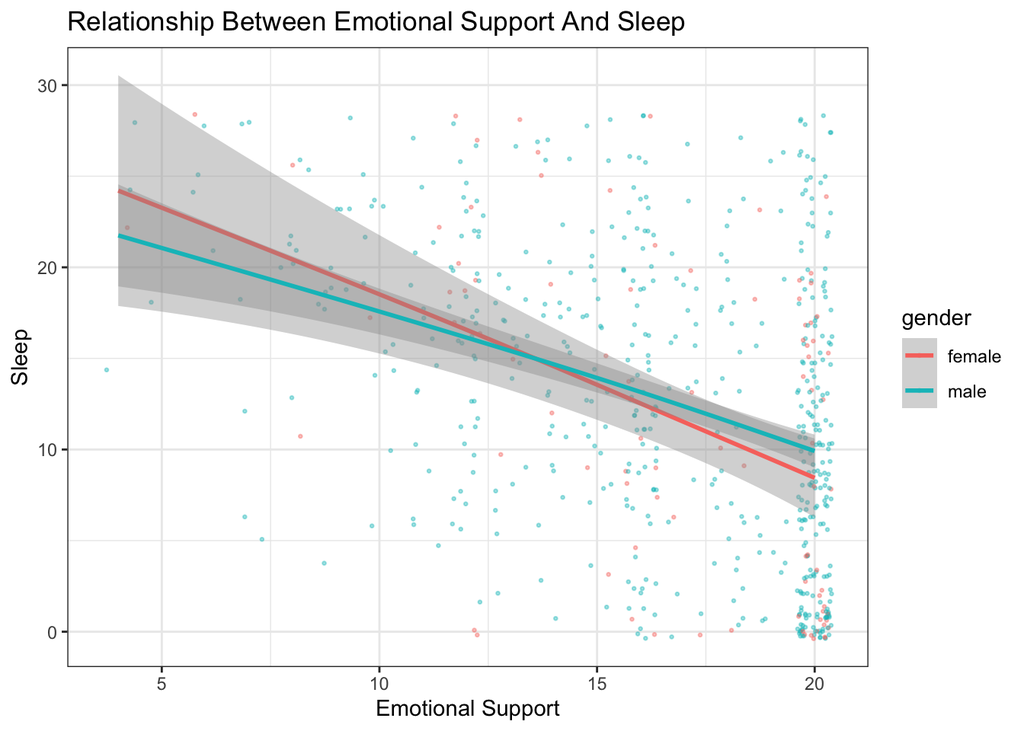

```
##
##  Pearson's product-moment correlation
##
## data:  data$es_score_promis and data$sleep_score
## t = -10.697, df = 607, p-value < 2.2e-16
## alternative hypothesis: true correlation is not equal to 0
## 95 percent confidence interval:
##  -0.4630546 -0.3292229
## sample estimates:
##       cor
## -0.398256
```

```
## Analysis of Variance Table
##
## Response: sleep_score
##                  Df Sum Sq Mean Sq  F value Pr(>F)
## es_score_promis   1   6532  6531.8 114.3554 <2e-16 ***
## gender            1     36    36.5   0.6389 0.4244
## Residuals       606  34614    57.1
## ---
## Signif. codes:  0 '***' 0.001 '**' 0.01 '*' 0.05 '.' 0.1 ' ' 1
```

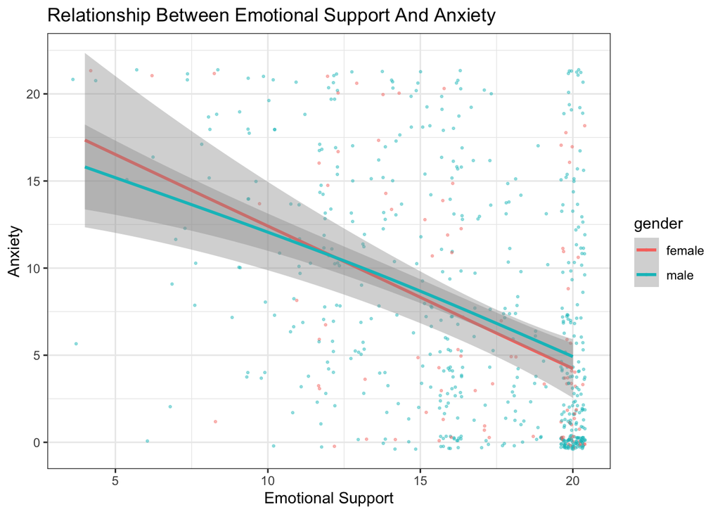

```
##
##  Pearson's product-moment correlation
##
## data:  data$es_score_promis and data$gad7_score
## t = -11.566, df = 607, p-value < 2.2e-16
## alternative hypothesis: true correlation is not equal to 0
## 95 percent confidence interval:
##  -0.4879238 -0.3575689
## sample estimates:
##        cor
## -0.4249468
```

```
## Analysis of Variance Table
##
## Response: gad7_score
##                  Df  Sum Sq Mean Sq  F value Pr(>F)
## es_score_promis   1  5292.3  5292.3 133.6133 <2e-16 ***
## gender            1    11.9    11.9   0.2992 0.5846
## Residuals       606 24003.1    39.6
## ---
## Signif. codes:  0 '***' 0.001 '**' 0.01 '*' 0.05 '.' 0.1 ' ' 1
```